# Using causal matching to understand the effects of misinformation on social media users

## The prevalence of misinformation on social media

- Misinformation<sup>1</sup> makes up only a **small fraction** of shared and consumed news online<sup>2</sup>,
- while being concentrated in politically extreme communities (Allen et al., 2020; Baribi-Bartov et al., 2024; González-Bailón et al., 2024)

$\rightarrow$ how **harmful** is misinformation on social media then?

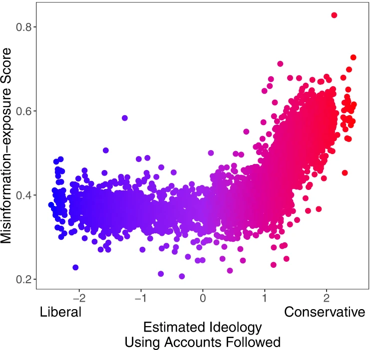

<sup>1</sup>=false information without intention to deceive (Wardle & Derakhshan, 2017);  
<sup>2</sup>depending on measurement and topic (Scharfbillig et al., 2026)

## Effects of misinformation beyond belief

### Individual-level experiments show

- reinforces partisan (mis-)beliefs (Ecker et al., 2022)
- secondary effects on uncertainty and distrust (Vaccari & Chadwick, 2020)
- negative emotions and hate (Lühring et al., 2024)

### But they suffer from [low ecological validity]

- artificial stimuli (also because deliberate exposure raises ethical concerns, Lazer et al., 2021)
- science-friendly samples (e.g., Lühring et al., 2024)
- cannot capture group- or platform-level interactions (Bak-Coleman et al., 2025)

$\rightarrow$ study effects of misinformation where it spreads

<sup>1</sup>=based on circumplex model (Russell, 1980) and  
constructivist view (Leach & Bou Zeineddine, 2021; Lindquist & Barrett, 2012)

## Effects of misinformation beyond exposure

### Observational social media data shows misinformation

- overlaps with moral outrage and hate speech (McLoughlin et al., 2024; Mosleh et al., 2024) $\rightarrow$ collective emotions<sup>1</sup> (Goldenberg et al., 2020)
- gets engagement (Juul & Ugander, 2021; Vosoughi et al., 2018)

### But it suffers from [low internal validity]

- confounded by other source cues, hateful and sensationalist language, …
  - e.g., comparing fact-checked false stories to neutral news reports (Vosoughi et al., 2018)

$\rightarrow$ calls to rethink causality and estimate effects **in the wild** (Budak et al., 2024; Lorenz-Spreen et al., 2022; Tay et al., 2024)

# What are the effects of misinformation on (collective) online interactions?

## Data collection

[figure not shown]

**Figure 2.** Data collection and pre-processing pipeline.

## Dataset descriptives

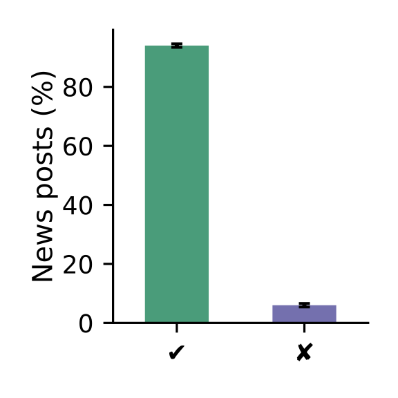

**Figure 3.** Proportions of untrustworthy (<60; purple) and trustworthy (>60; green) news tweets.

- robust 6% of untrustworthy news

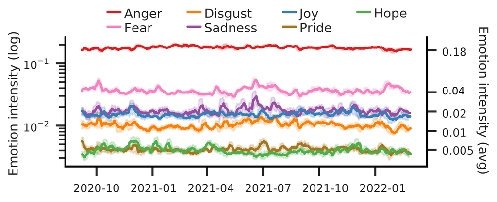

**Figure 4.** Probability of each news tweet containing each emotion (0-1), predicted by pol_emo_mDeBERTa2 (Widmann & Wich, 2022).

- anger and fear are overall higher across the whole observation period

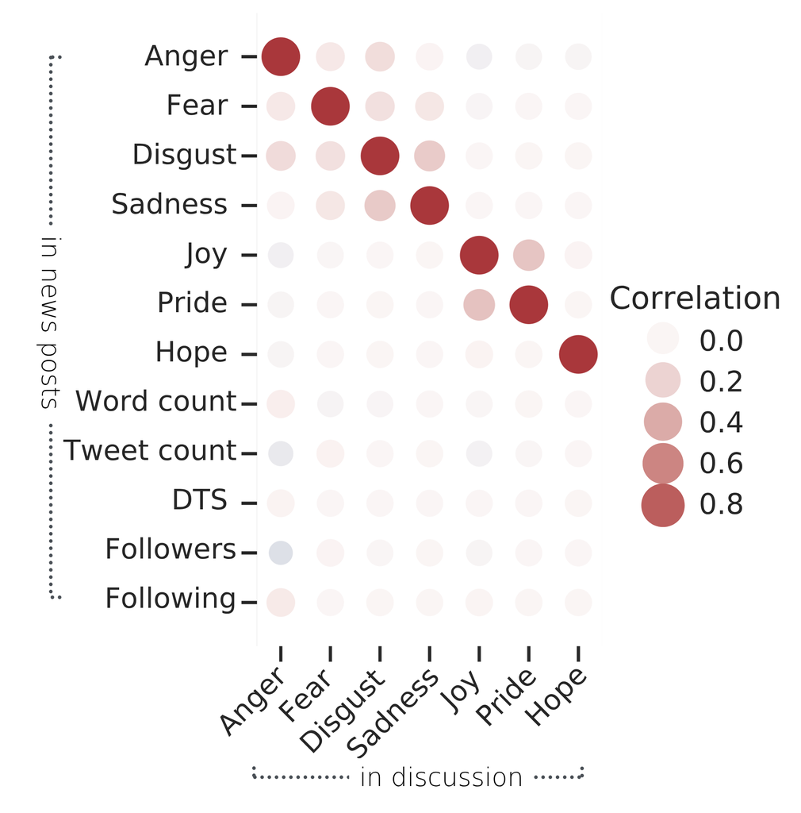

**Figure 5.** Correlations between the variables in news posts and discussions.

- emotional spillover into the discussions

## Data collection (2)

[figure not shown]

**Figure 6.** Data collection and pre-processing pipeline.

## Matching as a middle ground

- keeps the **naturalistic context** of platform data
- builds a **synthetic control group** comparable on observed confounders $\rightarrow$ blocks backdoor paths (Ho et al., 2007; Pearl & Mackenzie, 2019)

[figure not shown]

**Figure 7.** Directed Acylic Graph (DAG) with matched; treatment; outcome.

## Matching as a middle ground

- keeps the **naturalistic context** of platform data
- builds a **synthetic control group** comparable on observed confounders $\rightarrow$ blocks backdoor paths (Ho et al., 2007; Pearl & Mackenzie, 2019)
- evaluate performance based on differences

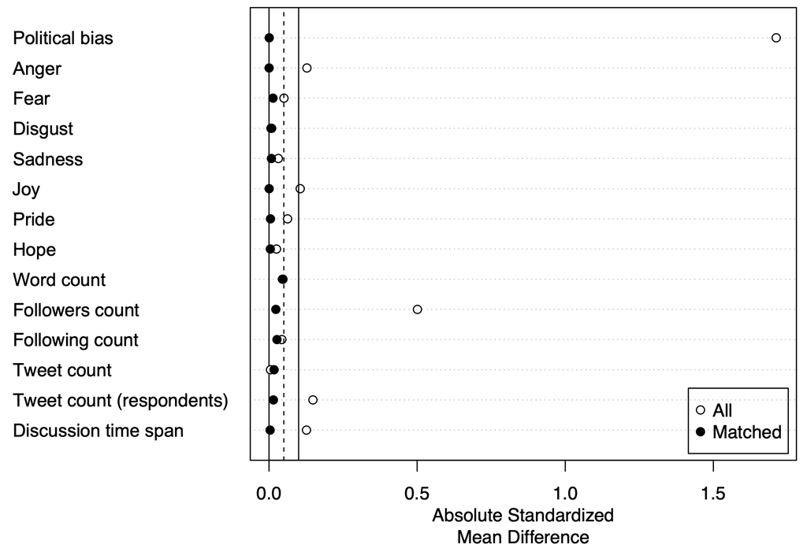

**Figure 8.** Matching with Nearest Neighbor and Mahalanobis distance (Ho et al., 2025).

## Confounder-adjusted effects on engagement

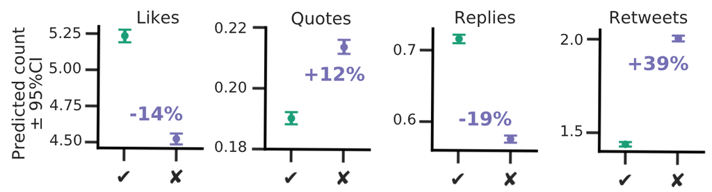

**Figure 9.** Marginal effects estimated by zero-inflated negative binomial models (bootstrapped 95% CIs).

$\uparrow$ **more** retweets for tweets with untrustworthy news sources

$\downarrow$ but **fewer** likes & replies

## Confounder-adjusted effects on emotions

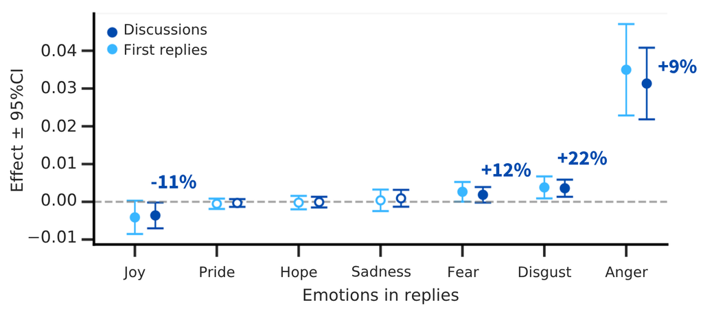

**Figure 10.** ATE estimated by linear regression (95% CI represent 10,000 bootstraps).

$\uparrow$ **more** anger, disgust and fear

$\downarrow$ and **less** joy in response to untrustworthy sources

## Self-selection dynamics

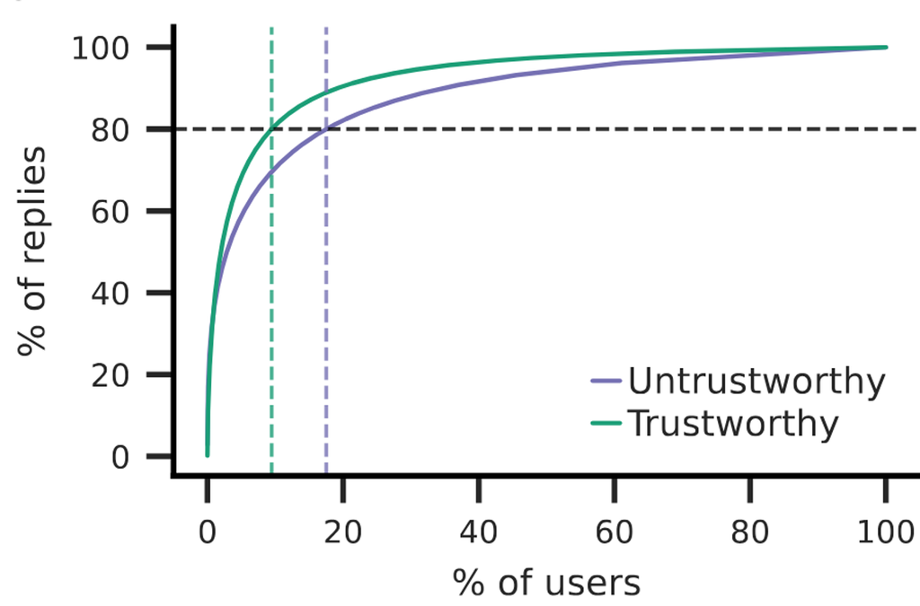

**Figure 11.** Panel a: CDF of reply contributions (dashed = 80% threshold); Panel b: Anger for top contributors (accounting for 80% of replies).

## Self-selection dynamics

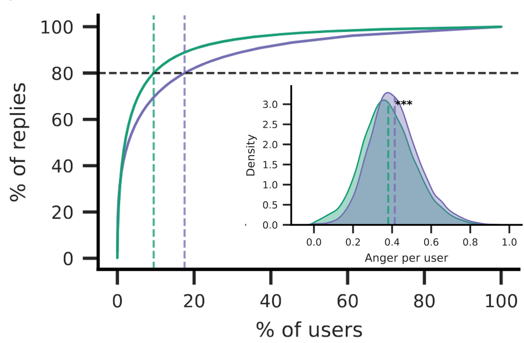

**Figure 11.** Panel a: CDF of reply contributions (dashed = 80% threshold); Panel b: Anger for top contributors (accounting for 80% of replies).

$\rightarrow$ angrier users preferentially engage, creating self-reinforcement

[figure not shown]

**Figure 12.** Directed Acylic Graph (DAG) with matched; *dashed* = unobserved; **who replies** = part of the effect, not matched.

## Conclusion

- Sources with lower trustworthiness have lower reach overall $\rightarrow$ misinformation is a contained problem (Allen et al., 2020)
  - *But* it spreads through reshares and quote reshares (in line with Guess et al., 2023’s de-activation)
- Sources with low trustworthiness predict anger, disgust and fear expressions in following discussions (McLoughlin et al., 2024; Mosleh et al., 2024)
  - Most likely driven by a motivated minority with preferences for hostile content (Petersen et al., 2023; Robertson et al., 2023)

> Limitations:  
> - **Source $\neq$ claim:** we estimate effects of source trustworthiness, not of false claims in single posts as well as excluding non-textual content (Nenno et al., 2026);  
> - **Unobserved confounders:** topic, timing, algorithmic exposure $\rightarrow$ tweet-level topics, causal sensitivity analyses, debiasing;  
> - **Missing data:** deleted tweets and suspended accounts

## Thank you!

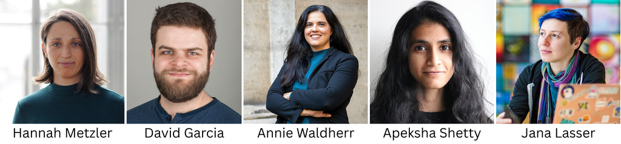

Email: jula.luehring@gesis.org

Bluesky: [@julaluehring.bsky.social](https://bsky.app/profile/julaluehring.bsky.social)

Website: julaluehring.github.io

## References

Allen, J., Howland, B., Mobius, M., Rothschild, D., & Watts, D. J. (2020). Evaluating the fake news problem at the scale of the information ecosystem. *Science Advances*, *6*(14), eaay3539. https://doi.org/10.1126/sciadv.aay3539

Bak-Coleman, J., Lewandowsky, S., Lorenz-Spreen, P., Narayanan, A., Orben, A., & Oswald, L. (2025). *Moving towards informative and actionable social media research* (arXiv:2505.09254). arXiv. https://doi.org/10.48550/arXiv.2505.09254

Baribi-Bartov, S., Swire-Thompson, B., & Grinberg, N. (2024). Supersharers of fake news on Twitter. *Science*, *384*(6699), 979–982. https://doi.org/10.1126/science.adl4435

Budak, C., Nyhan, B., Rothschild, D. M., Thorson, E., & Watts, D. J. (2024). Misunderstanding the harms of online misinformation. *Nature*, *630*(8015), 45–53. https://doi.org/10.1038/s41586-024-07417-w

Ecker, U. K. H., Lewandowsky, S., Cook, J., Schmid, P., Fazio, L. K., Brashier, N., Kendeou, P., Vraga, E. K., & Amazeen, M. A. (2022). The psychological drivers of misinformation belief and its resistance to correction. *Nature Reviews Psychology*, *1*(1), 13–29. https://doi.org/10.1038/s44159-021-00006-y

Goldenberg, A., Garcia, D., Halperin, E., & Gross, J. J. (2020). Collective Emotions. *Current Directions in Psychological Science*, *29*(2), 154–160. https://doi.org/10.1177/0963721420901574

González-Bailón, S., Lazer, D., Barberá, P., Godel, W., Allcott, H., Brown, T., Crespo-Tenorio, A., Freelon, D., Gentzkow, M., Guess, A. M., Iyengar, S., Kim, Y. M., Malhotra, N., Moehler, D., Nyhan, B., Pan, J., Rivera, C. V., Settle, J., Thorson, E., … Tucker, J. A. (2024). The Diffusion and Reach of (Mis)Information on Facebook During the U.S. 2020 Election. *Sociological Science*, *11*, 1124–1146. https://doi.org/10.15195/v11.a41

Guess, A. M., Malhotra, N., Pan, J., Barberá, P., Allcott, H., Brown, T., Crespo-Tenorio, A., Dimmery, D., Freelon, D., Gentzkow, M., González-Bailón, S., Kennedy, E., Kim, Y. M., Lazer, D., Moehler, D., Nyhan, B., Rivera, C. V., Settle, J., Thomas, D. R., … Tucker, J. A. (2023). How do social media feed algorithms affect attitudes and behavior in an election campaign? *Science*, *381*(6656), 398–404. https://doi.org/10.1126/science.abp9364

Ho, D., Imai, K., King, G., & Stuart, E. A. (2007). Matching as Nonparametric Preprocessing for Reducing Model Dependence in Parametric Causal Inference. *Political Analysis*, *15*(3), 199–236. https://doi.org/10.1093/pan/mpl013

Ho, D., Imai, K., King, G., Stuart, E., Whitworth, A., & Greifer, N. (2025). *MatchIt: Nonparametric Preprocessing for Parametric Causal Inference*.

Juul, J. L., & Ugander, J. (2021). Comparing information diffusion mechanisms by matching on cascade size. *Proceedings of the National Academy of Sciences*, *118*(46), e2100786118. https://doi.org/10.1073/pnas.2100786118

Lazer, D., Hargittai, E., Freelon, D., Gonzalez-Bailon, S., Munger, K., Ognyanova, K., & Radford, J. (2021). Meaningful measures of human society in the twenty-first century. *Nature*, *595*(7866), 189–196. https://doi.org/10.1038/s41586-021-03660-7

Leach, C. W., & Bou Zeineddine, F. (2021). A Systems View of Emotion in Socio-political Context. *Affective Science*, *2*(4), 353–362. https://doi.org/10.1007/s42761-021-00051-z

Lindquist, K. A., & Barrett, L. F. (2012). A functional architecture of the human brain: Emerging insights from the science of emotion. *Trends in Cognitive Sciences*, *16*(11), 533–540. https://doi.org/10.1016/j.tics.2012.09.005

Lorenz-Spreen, P., Oswald, L., Lewandowsky, S., & Hertwig, R. (2022). A systematic review of worldwide causal and correlational evidence on digital media and democracy. *Nature Human Behaviour*, 1–28. https://doi.org/10.1038/s41562-022-01460-1

Lühring, J., Shetty, A., Koschmieder, C., Garcia, D., Waldherr, A., & Metzler, H. (2024). Emotions in misinformation studies: Distinguishing affective state from emotional response and misinformation recognition from acceptance. *Cognitive Research: Principles and Implications*, *9*(1), 82. https://doi.org/10.1186/s41235-024-00607-0

McLoughlin, K. L., Brady, W. J., Goolsbee, A., Kaiser, B., Klonick, K., & Crockett, M. J. (2024). Misinformation exploits outrage to spread online. *Science*, *386*(6725), 991–996. https://doi.org/10.1126/science.adl2829

Mosleh, M., Cole, R., & Rand, D. G. (2024). Misinformation and harmful language are interconnected, rather than distinct, challenges. *PNAS Nexus*, *3*(3), pgae111. https://doi.org/10.1093/pnasnexus/pgae111

Mosleh, M., & Rand, D. G. (2022). Measuring exposure to misinformation from political elites on Twitter. *Nature Communications*, *13*(1), 7144. https://doi.org/10.1038/s41467-022-34769-6

Nenno, S., Puschmann, C., Fuławka, K., & Lorenz-Spreen, P. (2026). *Political disinformation concentrates in repeated claims across media* (p6yh9_v3). SocArXiv.

Pearl, J., & Mackenzie, D. (2019). *The Book of Why*. Penguin Books.

Petersen, M. B., Osmundsen, M., & Arceneaux, K. (2023). The “Need for Chaos” and Motivations to Share Hostile Political Rumors. *American Political Science Review*, 1–20. https://doi.org/10.1017/S0003055422001447

Robertson, R. E., Green, J., Ruck, D. J., Ognyanova, K., Wilson, C., & Lazer, D. (2023). Users choose to engage with more partisan news than they are exposed to on Google Search. *Nature*, *618*(7964), 342–348. https://doi.org/10.1038/s41586-023-06078-5

Russell, J. A. (1980). A circumplex model of affect. *Journal of Personality and Social Psychology*, *39*(6), 1161–1178. https://doi.org/10.1037/h0077714

Scharfbillig, M., Lewandowsky, S., Altay, S., Van, A. M., Kozyreva, A., Hertwig, R., Lorenz-Spreen, P., Diresta, R., Valenzuela, S., Egidy, S., Quattrociocchi, W., & Orben, A. (2026). *Fractured reality*. https://doi.org/10.2760/9358883

Tay, L. Q., Hurlstone, M., Jiang, Y., Platow, M. J., Kurz, T., & Ecker, U. K. H. (2024). Causal inference in misinformation and conspiracy research. *Advances.in/Psychology*, *2*, e69941. https://doi.org/10.56296/aip00023

Vaccari, C., & Chadwick, A. (2020). Deepfakes and Disinformation: Exploring the Impact of Synthetic Political Video on Deception, Uncertainty, and Trust in News. *Social Media + Society*, *6*(1), 2056305120903408. https://doi.org/10.1177/2056305120903408

Vosoughi, S., Roy, D., & Aral, S. (2018). The spread of true and false news online. *Science*, *359*(6380), 1146–1151. https://doi.org/10.1126/science.aap9559

Wardle, C., & Derakhshan, H. (2017). Information Disorder: Toward an Interdisciplinary Framework for Research and Policymaking. *Council of Europe Report*. https://doi.org/http://tverezo.info/wp-content/uploads/2017/11/PREMS-162317-GBR-2018-Report-desinformation-A4-BAT.pdf

Widmann, T., & Wich, M. (2022). Creating and Comparing Dictionary, Word Embedding, and Transformer-Based Models to Measure Discrete Emotions in German Political Text. *Political Analysis*, 1–16. https://doi.org/10.1017/pan.2022.15